# Krigeage avec R

Eric Marcon

19 décembre 2023

Abstract

Techniques pour interpoler les valeurs d’une variable continue.

Pour cartographier facilement une variable continue, 5 méthodes sont disponibles, dans les packages **akima**, **spatstat**, **spatial**, **gstat** et **automap**. Les deux premiers fournissent des méthodes d’interpolation: **spatstat** est le meilleur choix. Les trois derniers permettent le krigeage. **gstat** donne un contrôle précis sur les méthodes alors que **automap** automatise la procédure pour la rendre accessible aux non-spécialistes.

Des méthodes plus élaborées ne sont pas traitées ici :

# 1 Interpolation et cartographie locales

## 1.1 Création des données

Les données représentent le niveau de concentration spatiale locale autour de points (Marcon et Puech 2023).

Un jeu de deux types de points est généré dans une fenêtre carrée. Les cas sont générés par un processus de Matérn (Matérn 1960) avec $\kappa$ agrégats (attendus) de $\mu$ points (attendus) dans un cercle de rayon *scale*. Les contrôles suivent un processus de Poisson dont la densité $\lambda$ décroit exponentiellement vers le haut de la carte.

```r
library("tidyverse")
library("dbmss")
# Simulation of cases (clusters)
rMatClust(kappa = 10, scale = 0.05, mu = 10) %>%
  as.wmppp ->
  CASES
CASES$marks$PointType <- "Cases"
# Number of points
CASES$n
```

```
## [1] 97
```

```r
# Simulation of controls (random distribution)
rpoispp(function(x, y) {1000 * exp(-2 * y)}) %>%
  as.wmppp ->
  CONTROLS
CONTROLS$marks$PointType <-"Controls"
# Number of points
CONTROLS$n
```

```
## [1] 435
```

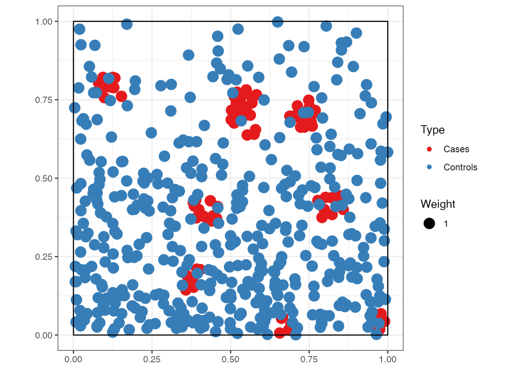

```r
# Mixed patterns (cases and controls)
ALL <- superimpose(CASES, CONTROLS)
autoplot(ALL)
```

La valeur de la concentration relative autour de chaque cas à la distance $r=0,1$ est définie comme le rapport entre la proportion de cas observés et la proportion moyenne sur tout le domaine d’étude. Si elle est supérieure à 1, on observe plus de voisins qu’attendu.

La valeur est calculée en chaque point et stockée dans un objet de type `fv` dont les valeurs sont récupérées pour produire un dataframe.

```r
# Choose the distance to plot
Distance <- 0.1

# Calculate the M values to plot
ALL %>%
  Mhat(
    r = c(0, Distance),
    ReferenceType = "Cases",
    NeighborType = "Cases",
    Individual = TRUE
  ) ->
  M_TheoEx

# Make a dataframe with x, y and M
the_df <- data.frame(
  x = CASES$x,
  y = CASES$y,
  z = as.numeric(as.data.frame(M_TheoEx)[2, -(1:3)])
)
```

A ce stade, nous disposons d’un tableau contenant les coordonnées et une valeur décrivant chaque point. Seuls les cas sont conservés: les contrôles n’ont servi qu’à calculer la concentration relative.

Ce format de données est aussi générique que possible.

```r
head(the_df)
```

```
##            x         y        z
## 1 0.12834741 0.7888727 3.519886
## 2 0.15282281 0.7608785 3.687500
## 3 0.10257350 0.8022610 3.226562
## 4 0.09695011 0.7898824 3.366848
## 5 0.08039593 0.7800437 3.366848
## 6 0.12748183 0.7886126 3.519886
```

L’objectif est maintenant de cartographier la valeur $z$. La cartographie des points est très simple avec **sf**.

```r
library("sf")
```

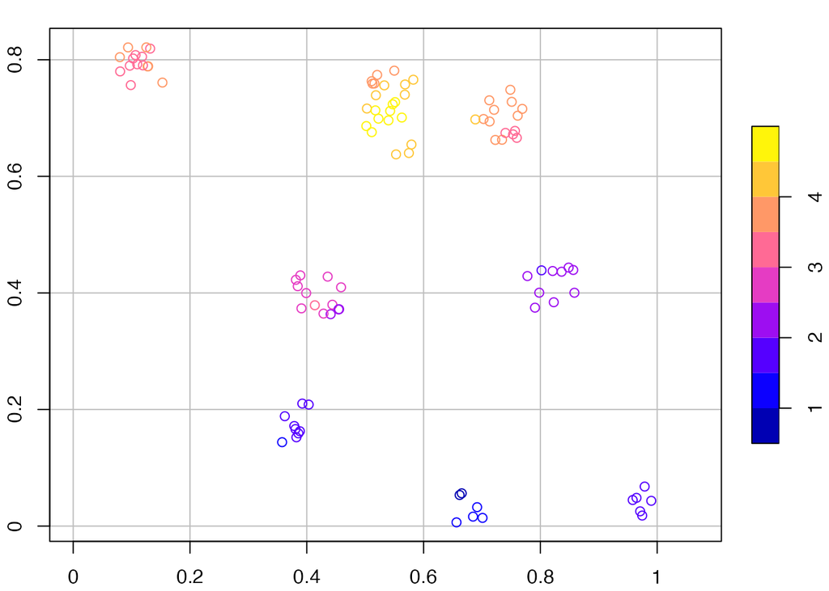

```r
the_df %>%
  st_as_sf(coords = c("x", "y")) %>%
  plot(graticule = TRUE, axes = TRUE, main="")
```

La sections suivante présente les méthodes nécessaire à la cartographie de la valeur interpolée ou krigée de $z$.

## 1.2 Cartographie

### 1.2.1 akima

La méthode d’Akima est une interpolation entre les valeurs des points, faite dans chaque triangle constitué par les triplets de points les plus proches. La valeur des points est conservée.

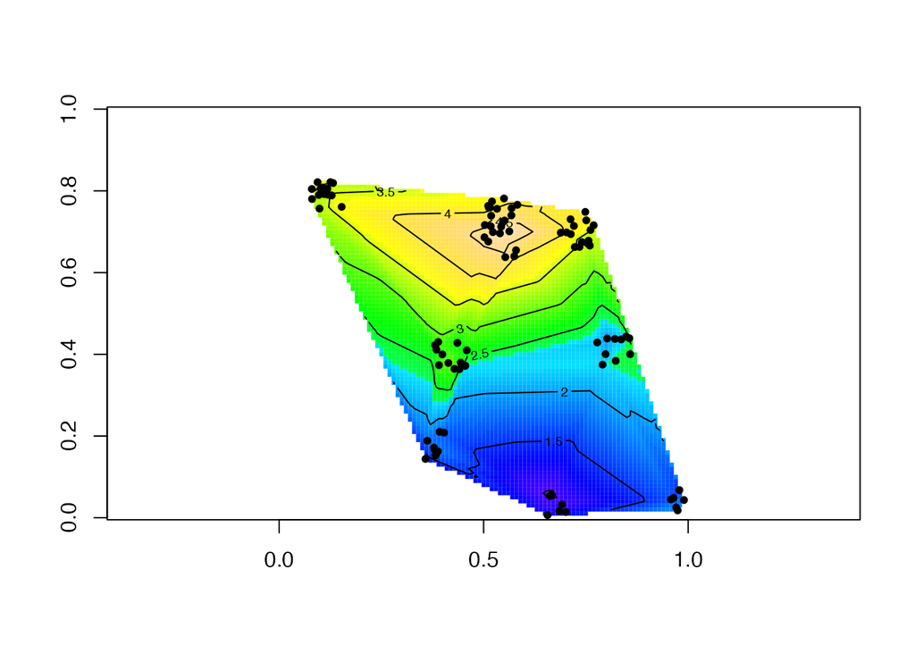

```r
library("akima")
# interp() function
akima_interp <- interp(
  # Coordinates
  x = the_df$x,
  y = the_df$y,
  # Value
  z = the_df$z,
  # Coordinates to interpolate
  xo = seq(from = 0, to = 1, by = .01),
  yo = seq(from = 0, to = 1, by = .01)
)

# Map
image(akima_interp, col = topo.colors(128, alpha = 1), asp = 1)
# Contour lines
contour(akima_interp, add = TRUE)
# Add the points
with(the_df, points(x, y, pch = 20))
```

L’interpolation se limite au polygone convexe contenant les points.

### 1.2.2 spatstat

La fonction `Smooth.ppp()` du package **spatstat** permet d’obtenir le même résultat mais ne se limite pas au polygone contenant les points.

Elle s’applique à un objet de type `ppp` (*planar point pattern*) à créer.

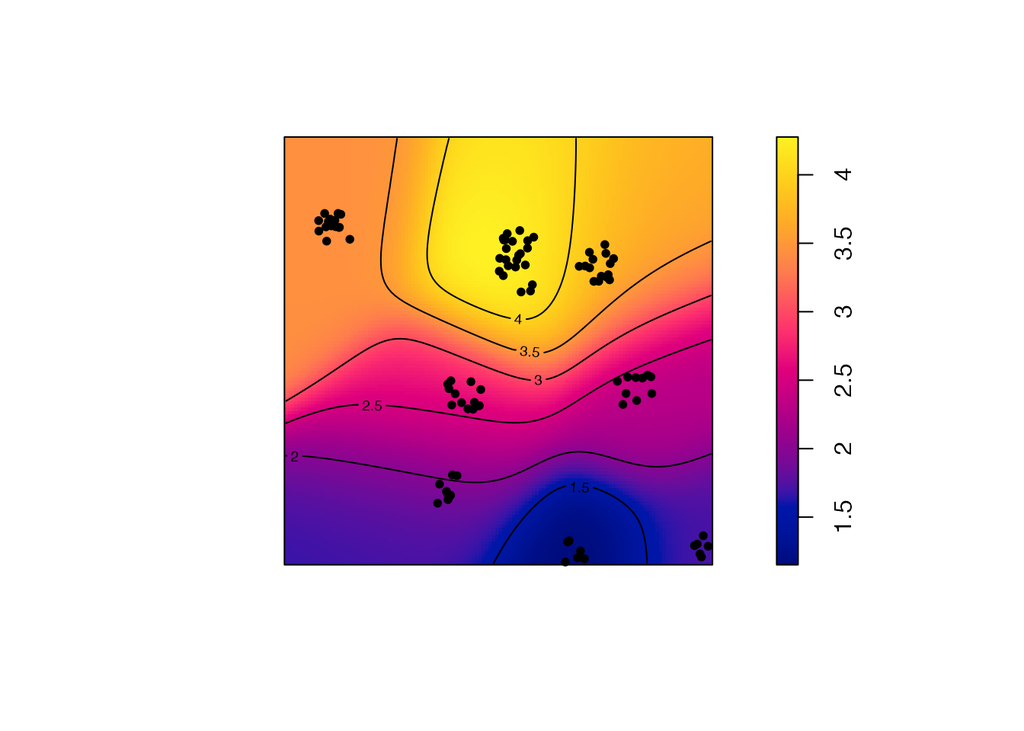

```r
library("spatstat")
the_df %>%
  # Create a ppp in a square window
  as.ppp(W = square(1)) %>%
  # Smooth it. The bandwidth is computed by bw.scott()
  Smooth(sigma = bw.scott(.)) ->
  spatstat_interp

# Plot the result
plot(spatstat_interp, main = "")
# Contour lines
contour(spatstat_interp, add = TRUE)
# Add the points
with(the_df, points(x, y, pch = 20))
```

Le choix de la largeur de bande est capital. La règle de Scott, implémentée dans `bw.scott()` est généralement efficace.

### 1.2.3 spatial

Le package **spatial** permet de kriger au lieu de simplement interpoler, mais renvoie des erreurs si la méthode de calcul de la covariance n’est pas exponentielle. L’ordre du polynôme du modèle et la distance de dépendance doivent être choisis explicitement.

```r
library("spatial")
```

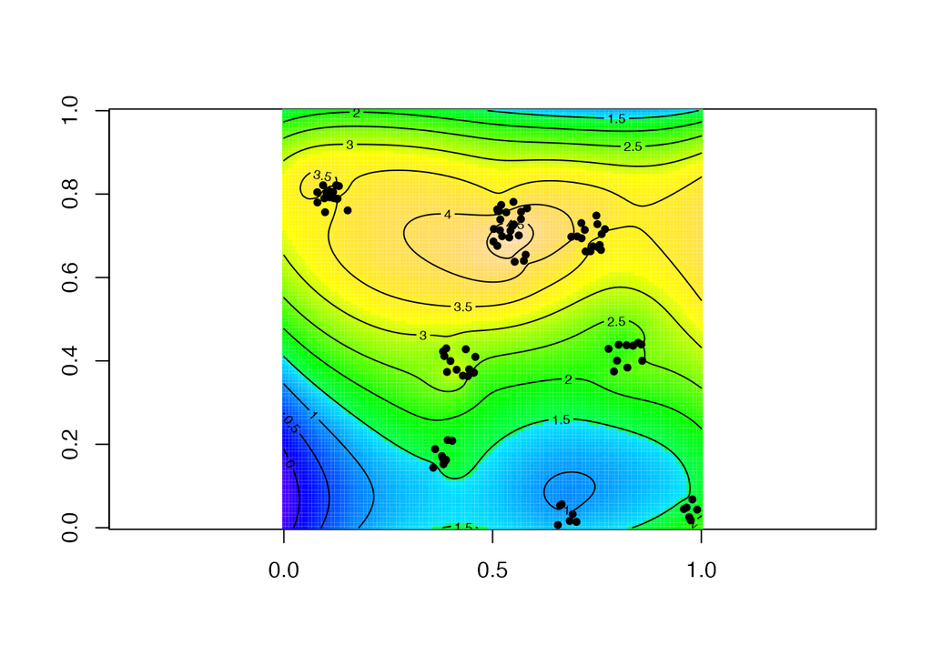

```r
# Function surf.gls() creates a trend surface object
surf.gls(
  np = 3,
  covmod = expcov,
  x = the_df$x,
  y = the_df$y,
  z = the_df$z,
  d = .5
) %>%
  # prmat() performs kriging over a grid
  prmat(xl= 0, xu = 1, yl = 0, yu = 1, n = 128) ->
  spatial_krige

# Map it
image(spatial_krige, col = topo.colors(128, alpha = 1), asp = 1)
# Contour lines
contour(spatial_krige, add = TRUE)
# Add the points
with(the_df, points(x, y, pch = 20))
```

### 1.2.4 gstat

**gstat** peut utiliser des objets spatiaux des packages **sp** et **sf**, qui remplace progressivement **sp**. **sp** est utilisé ici, **sf** le sera dans l’exemple utilisant un fond de carte.

```r
library("sp")
# Create a SpatialPointsDataFrame with the data
sp_spdf <- SpatialPointsDataFrame(
  # Coordinates are x and y
  coords = the_df[, 1:2],
  # Data is z
  data = the_df[3]
)
library("gstat")
# Empirical variogram
gstat::variogram(z ~ 1, data = sp_spdf) %>%
  # Fit a Gaussian model
  fit.variogram(vgm("Gau")) ->
  gstat_variogram

# Build an oject that describes all features of the model.
# The formula defines the trend
gstat_model <- gstat(
  formula = z ~ 1,
  locations = sp_spdf,
  model = gstat_variogram
)
# Préparation d'une grille de 128 points de côté
xy <- expand.grid((0:128) / 128, (0:128) / 128)
names(xy) <- c("x", "y")
gridded(xy) <- ~ x + y
# Calcul de la valeur de Richness sur les points de la grille (krigeage)
gstat_predict <- predict(gstat_model, newdata = xy)
```

```
## [using ordinary kriging]
```

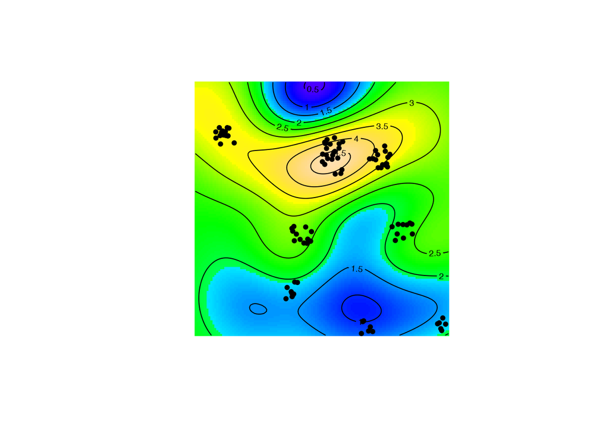

```r
# Carte
image(gstat_predict, col = topo.colors(128, alpha = 1), asp=1)
# Contour lines
contour(gstat_predict, add = TRUE)
# Add the points
with(the_df, points(x, y, pch = 20))
```

### 1.2.5 automap

Le package **automap** s’appuie sur **gstat** mais automatise toutes les étapes de sélection du modèle de covariance (celui qui s’ajuste le mieux aux données est choisi). Le modèle sélectionné est affiché dans le variogramme. La grille précédente peut être utilisée, mais une grille calculée à partir de la fenêtre de l’objet ``ppp` (librairie **spatstat**) est plutôt utilisée ici.

```r
library("spatstat")
# Build a ppp object
the_df %>%
  # Create a ppp in a square window
  as.ppp(W = square(1)) ->
  the_ppp
# Prepare a 256-square-point grid
xy <- gridcentres(the_ppp, 256, 256)
# Filter the nodes inside the window (not necessary here)
ok <- inside.owin(xy$x, xy$y, the_ppp)
# Format the grid as an sp object
sp_grid <- SpatialPoints(cbind(xy$x[ok], xy$y[ok]))
gridded(sp_grid) <- TRUE
# Krige the SpatialPointsDataFrame
library("automap")
automap_krige <- autoKrige(
  formula = z ~ 1,
  input_data = sp_spdf,
  new_data = sp_grid
)
```

```
## [using ordinary kriging]
```

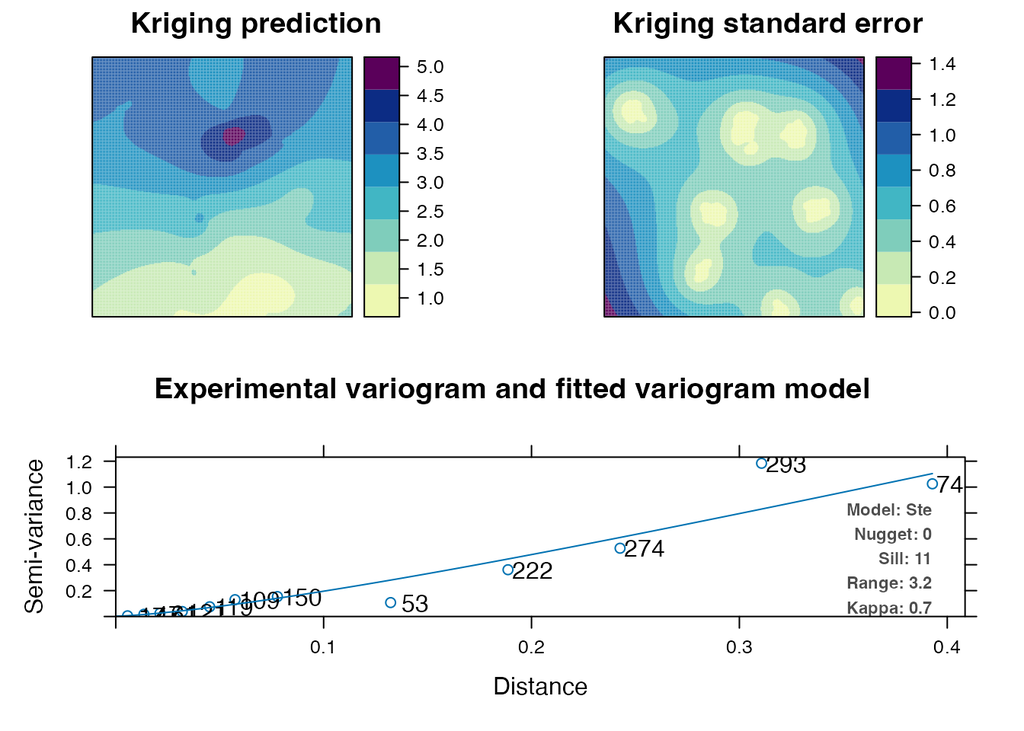

```r
# Result
plot(automap_krige)
```

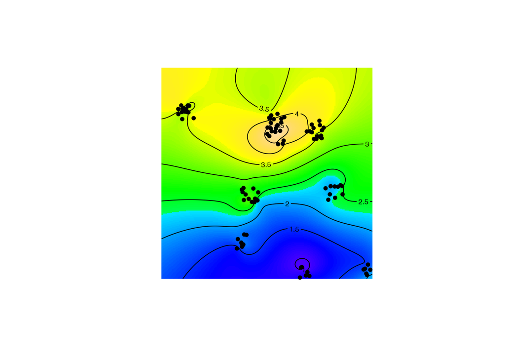

```r
# The usual map
image(automap_krige$krige_output, col = topo.colors(128, alpha = 1), asp = 1)
contour(automap_krige$krige_output, add=TRUE)
with(the_df, points(x, y, pch = 20))
```

# 2 Utilisation de fonds de carte

L’objectif est ici d’interpoler une variable continue du même type sur les centroïdes de polygones d’une carte vectorielle (un shapefile) plutôt que sur une grille.

Le code utilise les packages **geodata** (plutôt que **raster**) pour obtenir des fonds de carte et **sf** (plutôt que **sp**) pour manipuler les objets géographiques. Le package **gstat** utilisé pour le krigeage repose sur **sp**.

## 2.1 Obtention des cartes

Le package *geodata* permet de télécharger des fonds de carte administratifs, des modèles numériques de terrain, des cartes de climat : voir l’aide du package.

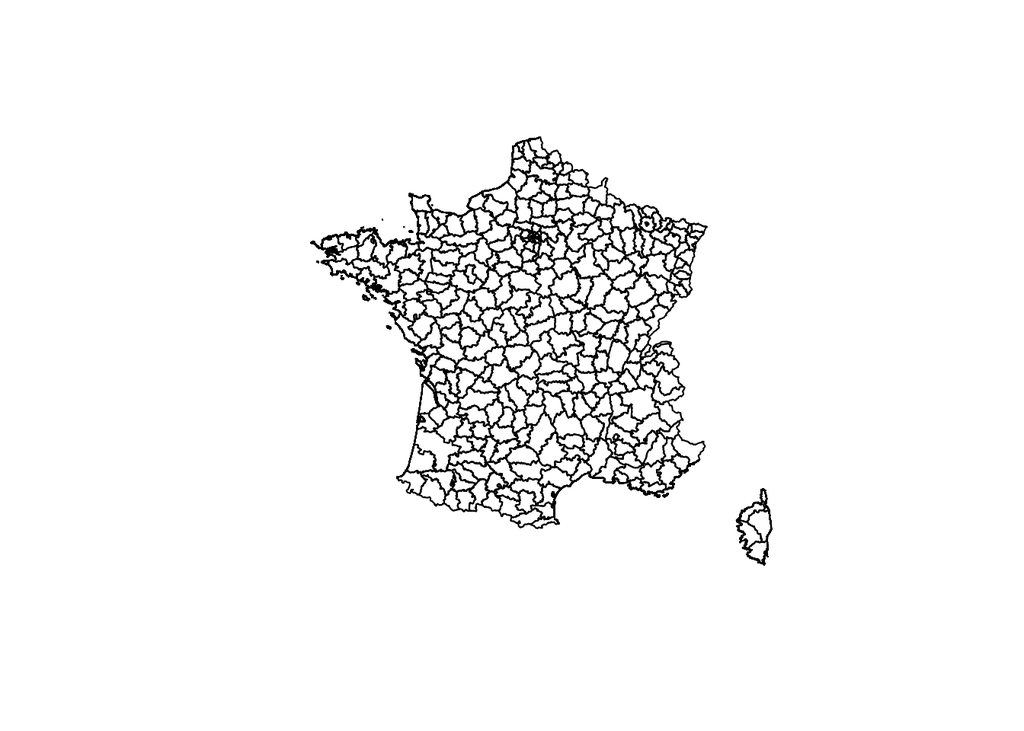

```r
library("geodata")
library("sf")

# Retrieving the shapefile for the boundaries of France's regions
gadm(country='FRA', level=3, path = "data") %>%
  # Convert to sf
  st_as_sf() %>%
  # Projection of France in Lambert 93
  st_transform(2154) ->
  France

# Map it
France %>% st_geometry() %>% plot()
```

## 2.2 Fabrication des données

Les données sont 100 points placés aléatoirement dans un rectangle contenant la France. Leur marque est une valeur numérique continue, augmentant linéairement de l’ouest vers l’est et avec la distance à la latitude moyenne, et contenant un bruit gaussien.

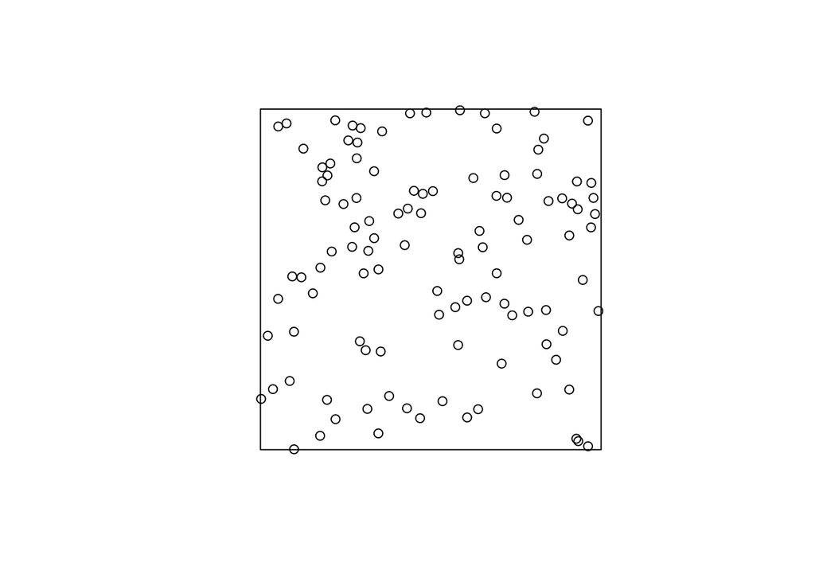

```r
library("spatstat")
# Draw in a Poisson process, 1000 expected points, in a 1x1 window
plot(X <- rpoispp(100), main = "")
```

```r
# Values of the mark
X$marks <- X$x + 3 * abs(X$y - 0.5) + rnorm(X$n, sd = 0.1)
# Rough projection on the map
X$x <- 8e+05 * X$x + 3e+05
X$y <- 9e+05 * X$y + 6200000
```

## 2.3 Interpolation

Les valeurs de $x$, $y$ et $z$ doivent être intégrées dans un objet `sf`.

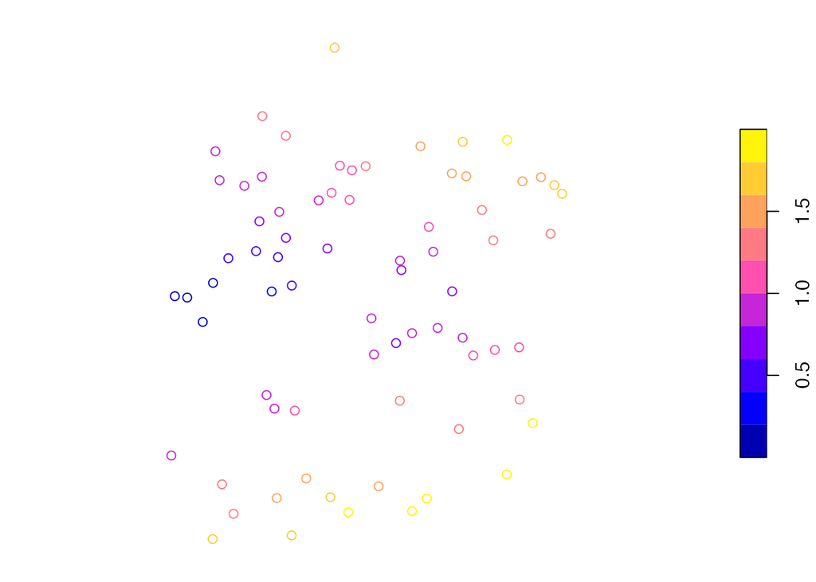

```r
X %>%
  # Make an sf object
  st_as_sf() %>%
  # Rename the marks columns
  rename(marks = spatstat.geom..marks.x.) %>%
  # Define the projection as Lambert 93
  st_set_crs(2154) %>%
  # Trim the object
  st_intersection(France) ->
  X.sf

# Plot the points
plot(X.sf["marks"], main = "")
```

L’interpolation est faite avec *gstat*.

```r
library("gstat")
# Empirical variogram
gstat::variogram(marks ~ 1, data = X.sf) %>%
  # Fit a Gaussian model
  fit.variogram(vgm("Gau")) ->
  gstat_variogram

# Build an oject that describes all features of the model.
X_geo <- gstat(
  formula = marks ~ 1,
  locations = X.sf,
  model = gstat_variogram
)
# Calculate the value of the marks on the centroids of polygons
X_prd <- predict(X_geo, newdata = France)
```

```
## [using ordinary kriging]
```

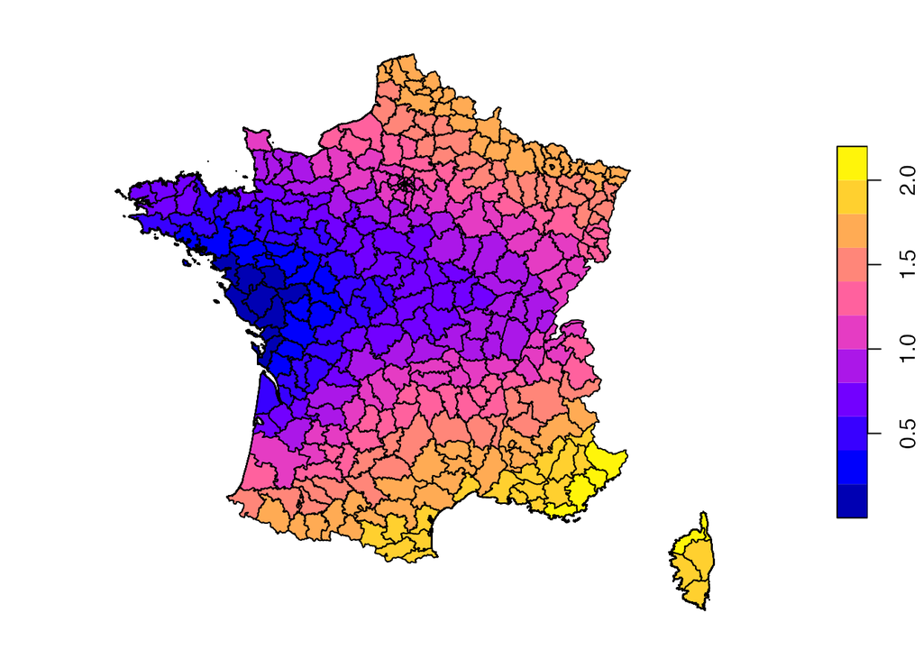

```r
# Final map
plot(X_prd["var1.pred"], main = "")
```

## 2.4 Carte

Une vraie carte peut être produite en ajoutant une échelle, une rose des vents, etc. avec le package **ggspatial**.

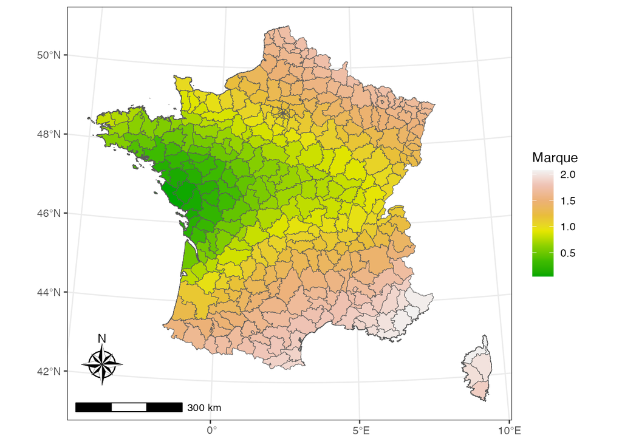

```r
library("ggspatial")

ggplot(data = X_prd) +
  # Variable to map
  geom_sf(aes(fill=var1.pred)) +
  # Color gradient
  scale_fill_gradientn(colours = terrain.colors(8)) +
  # Scale bar
  annotation_scale() +
  # North arrow
  annotation_north_arrow(
    pad_y = unit(1, "cm"),
    style = north_arrow_nautical()
  ) +
  # Legend title
  labs(fill = "Marque")
```

# References

Marcon, Éric, et Florence Puech. 2023. « Mapping Distributions in Non-Homogeneous Space with Distance-Based Methods ». *Journal of Spatial Econometrics* 4 (1): 13. https://doi.org/10.1007/s43071-023-00042-1.

Matérn, Bertil. 1960. « Spatial Variation ». *Meddelanden från Statens Skogsforskningsinstitut* 49 (5): 1‑144.

[^1]: http://rgeostats.free.fr/
[^2]: http://www.r-inla.org/spde-book